# Project 1 Rearch Paper - Housing Data Post COVID?

Mia Alecia Goins, Mak Trnka

2026-10-18

# A Peak Under the Hood!

**What does our raw unaltered data look like?**

```r
# Mia's File for the same dataset
housing = read.csv("C:/Users/flami/OneDrive/Documents/DATS6101/Project 1/RDC_Inventory_Core_Metrics_Metro_History(9-18-26).csv", header =TRUE)

# Mak's File for the same dataset
#housing = read.csv("/Users/maktrnka/Documents/RDC_Inventory_Core_Metrics_Metro_History.csv", header = TRUE)
head(housing, n=3)
```

```
##   month_date_yyyymm cbsa_code                         cbsa_title HouseholdRank
## 1            202608     35620 New York-Newark-Jersey City, NY-NJ             1
## 2            202608     31080 Los Angeles-Long Beach-Anaheim, CA             2
## 3            202608     16980    Chicago-Naperville-Elgin, IL-IN             3
##   median_listing_price median_listing_price_mm median_listing_price_yy
## 1               749000                 -0.0301                 -0.0145
## 2              1050000                 -0.0428                 -0.0455
## 3               395000                  0.0064                  0.0536
##   active_listing_count active_listing_count_mm active_listing_count_yy
## 1                36676                 -0.0323                  0.0320
## 2                20134                  0.0135                 -0.0032
## 3                15130                  0.0357                 -0.0604
##   median_days_on_market median_days_on_market_mm median_days_on_market_yy
## 1                    56                   0.0667                  -0.0345
## 2                    53                   0.0291                   0.0000
```

[output cut: 49 more lines]

Our data has 112850 observations with 47 measures.

# Let’s Get Relevant!

**Here we will clean up the data, then only select the data from June 2023 to August 2026, the month after the CDC’s official declaration of the end of COVID.**

```r
#add state column
metro_states = strsplit(housing$cbsa_title, ", ")
metro_states = unlist(metro_states)
states = metro_states[seq(2,length(metro_states),2)]
state = substring(states,1,2)
housing$state_ss = state # it counts DC as a state so there are 51

#cbsa_title and cbsa_code are factors
housing[,3] = as.factor(housing[,3])
housing[,2] = as.factor(housing[,2])

# add a month and a year column
housing$month_mm = housing[,1]%%100
housing$year_yyyy = housing[,1]%/%100

# date reformat and time constraint
housing[,1] = as.Date(paste(housing[,1],"01"),'%Y%m%d')
postCOVID_housing = housing[housing$month_date_yyyymm > "2023-05-01",]

#house rank, state, month, and year are factors
postCOVID_housing[,4] = as.factor(postCOVID_housing[,4]) # rank
postCOVID_housing[,48] = as.factor(postCOVID_housing[,48]) # state
postCOVID_housing[,49] = as.factor(postCOVID_housing[,49]) # month
postCOVID_housing[,50] = as.factor(postCOVID_housing[,50]) # year

#make sure its quality
quality_housing = subset(postCOVID_housing, quality_flag==0)
str(quality_housing)
```

```
## 'data.frame':    31827 obs. of  50 variables:
##  $ month_date_yyyymm                      : Date, format: "2026-08-01" "2026-08-01" ...
##  $ cbsa_code                              : Factor w/ 925 levels "10100","10140",..: 601 491 161 207 382 539 655 49 883 656 ...
##  $ cbsa_title                             : Factor w/ 925 levels "Aberdeen, SD",..: 598 491 161 207 382 538 655 49 881 656 ...
##  $ HouseholdRank                          : Factor w/ 925 levels "1","2","3","4",..: 1 2 3 4 5 6 7 8 9 10 ...
##  $ median_listing_price                   : int  749000 1050000 395000 425000 359000 490000 374900 419900 565000 475000 ...
##  $ median_listing_price_mm                : num  -0.0301 -0.0428 0.0064 -0.0319 -0.0028 -0.0101 -0.0255 -0.012 -0.0249 -0.0144 ...
##  $ median_listing_price_yy                : num  -0.0145 -0.0455 0.0536 -0.0116 -0.0164 -0.02 -0.0134 0.0118 -0.0582 -0.0481 ...
##  $ active_listing_count                   : int  36676 20134 15130 29549 35920 40908 13056 29580 15290 17707 ...
##  $ active_listing_count_mm                : num  -0.0323 0.0135 0.0357 -0.0065 0.0089 -0.0148 0.0141 0.0096 0.0057 0.0026 ...
##  $ active_listing_count_yy                : num  0.032 -0.0032 -0.0604 -0.0441 0.0218 ...
##  $ median_days_on_market                  : int  56 53 36 58 52 85 48 59 43 67 ...
##  $ median_days_on_market_mm               : num  0.0667 0.0291 0.0435 0.0741 0.04 ...
##  $ median_days_on_market_yy               : num  -0.0345 0 -0.027 0 0.0196 ...
##  $ new_listing_count                      : int  12992 8416 8780 9392 9512 9104 6240 8736 6696 6104 ...
```

[output cut: 36 more lines]

Our data has gone from 112850 observations to 31827 after the quality flagging and time constraint being post COVID (June 2023 - August 2026).

# Basic Summary Stats

**Exploring a little bit about our data**

```r
str(quality_housing)
```

```
## 'data.frame':    31827 obs. of  50 variables:
##  $ month_date_yyyymm                      : Date, format: "2026-08-01" "2026-08-01" ...
##  $ cbsa_code                              : Factor w/ 925 levels "10100","10140",..: 601 491 161 207 382 539 655 49 883 656 ...
##  $ cbsa_title                             : Factor w/ 925 levels "Aberdeen, SD",..: 598 491 161 207 382 538 655 49 881 656 ...
##  $ HouseholdRank                          : Factor w/ 925 levels "1","2","3","4",..: 1 2 3 4 5 6 7 8 9 10 ...
##  $ median_listing_price                   : int  749000 1050000 395000 425000 359000 490000 374900 419900 565000 475000 ...
##  $ median_listing_price_mm                : num  -0.0301 -0.0428 0.0064 -0.0319 -0.0028 -0.0101 -0.0255 -0.012 -0.0249 -0.0144 ...
##  $ median_listing_price_yy                : num  -0.0145 -0.0455 0.0536 -0.0116 -0.0164 -0.02 -0.0134 0.0118 -0.0582 -0.0481 ...
##  $ active_listing_count                   : int  36676 20134 15130 29549 35920 40908 13056 29580 15290 17707 ...
##  $ active_listing_count_mm                : num  -0.0323 0.0135 0.0357 -0.0065 0.0089 -0.0148 0.0141 0.0096 0.0057 0.0026 ...
##  $ active_listing_count_yy                : num  0.032 -0.0032 -0.0604 -0.0441 0.0218 ...
##  $ median_days_on_market                  : int  56 53 36 58 52 85 48 59 43 67 ...
##  $ median_days_on_market_mm               : num  0.0667 0.0291 0.0435 0.0741 0.04 ...
##  $ median_days_on_market_yy               : num  -0.0345 0 -0.027 0 0.0196 ...
##  $ new_listing_count                      : int  12992 8416 8780 9392 9512 9104 6240 8736 6696 6104 ...
```

[output cut: 36 more lines]

```r
xkablesummary(quality_housing)
```

Table: Statistics summary.

|  | month_date_yyyymm | cbsa_code | cbsa_title | HouseholdRank | median_listing_price | median_listing_price_mm | median_listing_price_yy | active_listing_count | active_listing_count_mm | active_listing_count_yy | median_days_on_market | median_days_on_market_mm | median_days_on_market_yy | new_listing_count | new_listing_count_mm | new_listing_count_yy | price_increased_count | price_increased_count_mm | price_increased_count_yy | price_increased_share | price_increased_share_mm | price_increased_share_yy | price_reduced_count | price_reduced_count_mm | price_reduced_count_yy | price_reduced_share | price_reduced_share_mm | price_reduced_share_yy | pending_listing_count | … |
| --- | --- | --- | --- | --- | --- | --- | --- | --- | --- | --- | --- | --- | --- | --- | --- | --- | --- | --- | --- | --- | --- | --- | --- | --- | --- | --- | --- | --- | --- | --- |
| Min | Min. :2023-06-01 | 10140 : 39 | Aberdeen, WA : 39 | 1 : 39 | Min. : 72450 | Min. :-0.27250 | Min. :-0.1000 | Min. : 11 | Min. :-0.4929 | Min. :-0.6512 | Min. : 9.0 | Min. :-0.7536 | Min. :-0.5991 | Min. : 2 | Min. :-0.8893 | Min. :-0.7000 | Min. : 0 | Min. :-1.000 | Min. :-1.000 | Min. :0.00000 | Min. :-2.21e-01 | Min. :-0.21370 | Min. : 0 | Min. :-1.0000 | Min. :-1.0000 | Min. :0.000 | Min. :-0.24080 | Min. :-0.29790 | Min. : 1 | … |
| Q1 | 1st Qu.:2024-03-01 | 10420 : 39 | Akron, OH : 39 | 2 : 39 | 1st Qu.: 249900 | 1st Qu.:-0.01810 | 1st Qu.:-0.0211 | 1st Qu.: 109 | 1st Qu.:-0.0323 | 1st Qu.: 0.0184 | 1st Qu.: 46.0 | 1st Qu.:-0.0602 | 1st Qu.:-0.0497 | 1st Qu.: 42 | 1st Qu.:-0.1485 | 1st Qu.:-0.1111 | 1st Qu.: 0 | 1st Qu.:-0.500 | 1st Qu.:-0.600 | 1st Qu.:0.00000 | 1st Qu.:-1.00e-03 | 1st Qu.:-0.00170 | 1st Qu.: 30 | 1st Qu.:-0.1304 | 1st Qu.:-0.0769 | 1st Qu.:0.119 | 1st Qu.:-0.02060 | 1st Qu.:-0.02010 | 1st Qu.: 47 | … |
| Median | Median :2025-01-01 | 10460 : 39 | Alamogordo, NM : 39 | 3 : 39 | Median : 325000 | Median : 0.00000 | Median : 0.0231 | Median : 234 | Median : 0.0201 | Median : 0.1571 | Median : 58.0 | Median : 0.0352 | Median : 0.0641 | Median : 92 | Median : 0.0000 | Median : 0.0191 | Median : 0 | Median :-0.107 | Median :-0.111 | Median :0.00000 | Median : 0.00e+00 | Median : 0.00000 | Median : 68 | Median : 0.0426 | Median : 0.1441 | Median :0.156 | Median : 0.00420 | Median : 0.00710 | Median : 104 | … |
| Mean | Mean :2024-12-31 | 10540 : 39 | Albany-Schenectady-Troy, NY: 39 | 4 : 39 | Mean : 376452 | Mean : 0.00308 | Mean : 0.0457 | Mean : 981 | Mean : 0.0221 | Mean : 0.1759 | Mean : 60.7 | Mean : 0.0240 | Mean : 0.0827 | Mean : 425 | Mean : 0.0354 | Mean : 0.0322 | Mean : 20 | Mean :-0.022 | Mean : 0.029 | Mean :0.00524 | Mean :-8.15e-05 | Mean :-0.00043 | Mean : 332 | Mean : 0.0809 | Mean : 0.2296 | Mean :0.158 | Mean : 0.00212 | Mean : 0.00624 | Mean : 477 | … |
| Q3 | 3rd Qu.:2025-11-01 | 10580 : 39 | Albany, OR : 39 | 5 : 39 | 3rd Qu.: 426944 | 3rd Qu.: 0.01950 | 3rd Qu.: 0.0878 | 3rd Qu.: 624 | 3rd Qu.: 0.0725 | 3rd Qu.: 0.3115 | 3rd Qu.: 72.0 | 3rd Qu.: 0.1176 | 3rd Qu.: 0.1898 | 3rd Qu.: 266 | 3rd Qu.: 0.1667 | 3rd Qu.: 0.1623 | 3rd Qu.: 8 | 3rd Qu.: 0.250 | 3rd Qu.: 0.273 | 3rd Qu.:0.00790 | 3rd Qu.: 6.00e-04 | 3rd Qu.: 0.00020 | 3rd Qu.: 190 | 3rd Qu.: 0.2273 | 3rd Qu.: 0.4250 | 3rd Qu.:0.194 | 3rd Qu.: 0.02600 | 3rd Qu.: 0.03300 | 3rd Qu.: 303 | … |
| Max | Max. :2026-08-01 | 10740 : 39 | Albuquerque, NM : 39 | 7 : 39 | Max. :5972500 | Max. : 0.62030 | Max. : 0.5000 | Max. :51989 | Max. : 1.0000 | Max. : 1.7000 | Max. :164.0 | Max. : 1.2083 | Max. : 1.0000 | Max. :22704 | Max. : 9.0000 | Max. : 0.7000 | Max. :1328 | Max. :35.000 | Max. :44.000 | Max. :0.22100 | Max. : 2.21e-01 | Max. : 0.22100 | Max. :16616 | Max. :10.0000 | Max. :12.0000 | Max. :0.430 | Max. : 0.30870 | Max. : 0.28310 | Max. :25694 | … |
| NA | NA | (Other):31593 | (Other) :31593 | (Other):31593 | NA | NA | NA | NA | NA | NA | NA | NA | NA | NA | NA’s :7 | NA’s :12 | NA | NA’s :16259 | NA’s :16414 | NA | NA | NA | NA | NA’s :57 | NA’s :72 | NA | NA | NA | NA’s :85 | … |

## A little bit about our data set

This data set is from Realtor.com which is described on the website as a, “Residential Real Estate Data Library [that] is based on the extensive Realtor.com database of MLS-listed for-sale homes,” (Realtor.Com Real Estate Data and Market Trends for Download, n.d.). Since this data is collected from only MLS-listed for-sale homes only licensed real estate professionals can input listings directly. There are ways to pay a flat fee to add one’s house to the MLS but that is usually goes through, “licensed brokers who charge a one-time fee to post your listing on the local MLS,” (Haddad, 2026).

Looking on Realtor.com it has data visualizations of their data studying the markets, there are also different MLS reports that exist outside Realtor.com’s, but most of the reports on Realtor.com are summary statistics and just report on counts over time. No deeper analysis into relationships between variables within the website alone.

Looking at our numerical variables we noticed large ranges within variables like pending_listing_count and price increase/reduction count, so shifting to ratio data or share data gave us more normalized comparisons, and led us to think of 4 questions that we wanted to explore further.

# What’s SMART About the Data?

**Let’s explore our SMART Questions!**

## Data Preparation for Questions 1 and 2

Questions 1 and 2 compare each metro’s median listing price in June 2023 with its price in August 2026. We keep only those two months, place each metro in a size tier using its June 2023 household rank, and calculate one price change per metro.

```r
housing_start <- quality_housing %>%
  dplyr::filter(year_yyyy == 2023, month_mm == 06) %>%
  dplyr::arrange(HouseholdRank, cbsa_code) %>%
  dplyr::transmute(
    cbsa_code,
    cbsa_title,
    HouseholdRank,
    price_2023 = median_listing_price,
    pending_2023 = pending_ratio,
    metro_size_group = factor(
      dplyr::ntile(HouseholdRank, 4),
      levels = 1:4,
      labels = c(
        "Tier 1 (Largest)",
        "Tier 2 (Upper-Mid)",
        "Tier 3 (Lower-Mid)",
        "Tier 4 (Smallest)"
      )
    )
  )

housing_end <- quality_housing %>%
  dplyr::filter(year_yyyy == 2026, month_mm == 08) %>%
  dplyr::transmute(
    cbsa_code,
    price_2026 = median_listing_price,
    pending_2026 = pending_ratio
  )

# One row per metro with both endpoints.
metro_endpoints <- housing_start %>%
  dplyr::inner_join(housing_end, by = "cbsa_code") %>%
  dplyr::filter(
    is.finite(price_2023),
    is.finite(price_2026),
    price_2023 > 0,
    price_2026 > 0
  ) %>%
  dplyr::mutate(
    price_change_pct = 100 * (price_2026 - price_2023) / price_2023,
    log_price_change = log(price_2026 / price_2023)
  )

nrow(metro_endpoints)
```

```
## [1] 730
```

## Question 1

**After COVID (from June 2023 to August 2026), did the average change in median listing price differ across the four metro-size tiers?**

### EDA

It’s important to see the variation in our data before constructing our hypotheses. So let’s first plot the percent change in median listing price across all metros.

```r
q1 <- subset(
  metro_endpoints,
  is.finite(log_price_change) &
  !is.na(metro_size_group)
)

stopifnot(anyDuplicated(q1$cbsa_code) == 0)

table(q1$metro_size_group)
```

```
##
##   Tier 1 (Largest) Tier 2 (Upper-Mid) Tier 3 (Lower-Mid)  Tier 4 (Smallest)
##                195                194                182                159
```

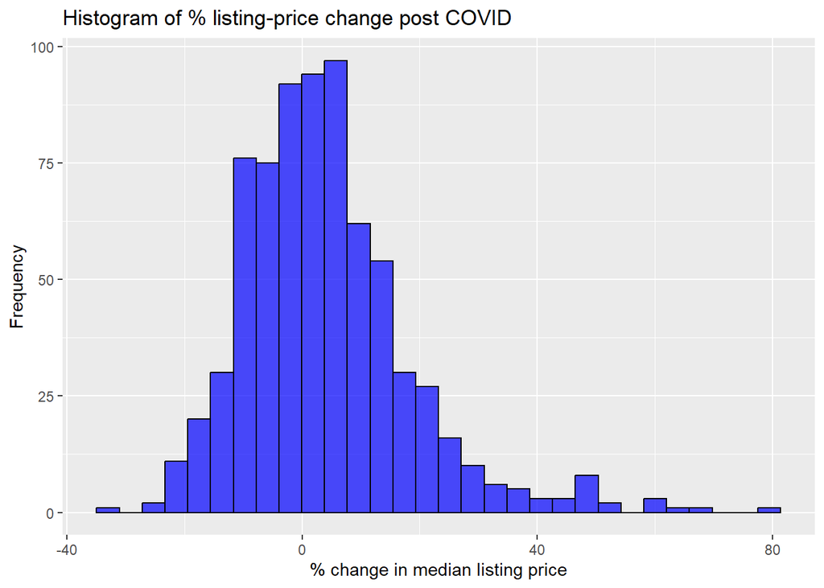

```r
q1_colors <- c("blue", "lightblue", "gold", "orange")

ggplot(data = q1, aes(price_change_pct)) +
  geom_histogram(bins = 30,
                 col = "black",
                 fill = "blue",
                 alpha = .7) + # opacity
  labs(x = "% change in median listing price", y = "Frequency") +
  labs(title = "Histogram of % listing-price change post COVID")
```

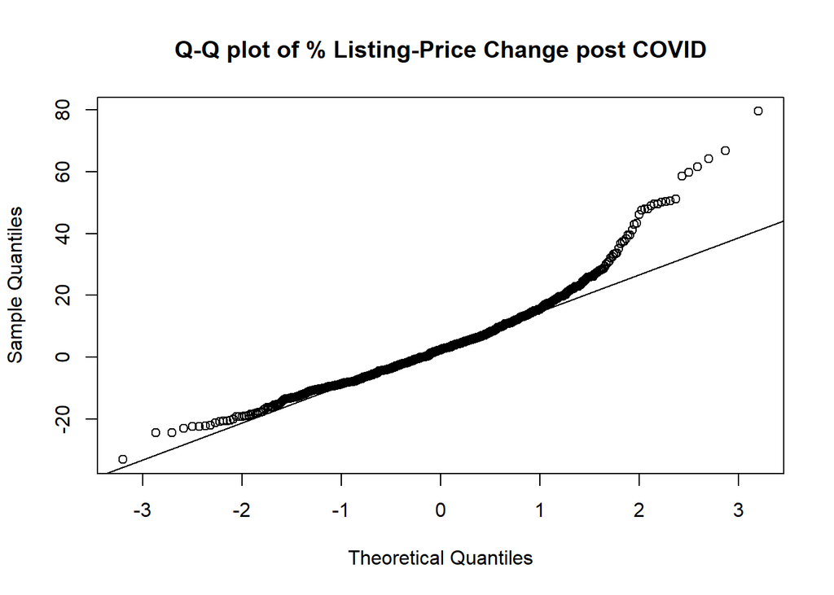

```r
qqnorm(q1$price_change_pct, main = "Q-Q plot of % Listing-Price Change post COVID")
qqline(q1$price_change_pct)
```

A percent change can’t fall below -100% but has no upper limit, so percent changes tend to be right skewed. So let’s log transform our data, using $\log(\text{price}_{2026} / \text{price}_{2023})$, then plot again. For small changes the log change is close to the percent change (a log change of 0.10 is about 10.5%).

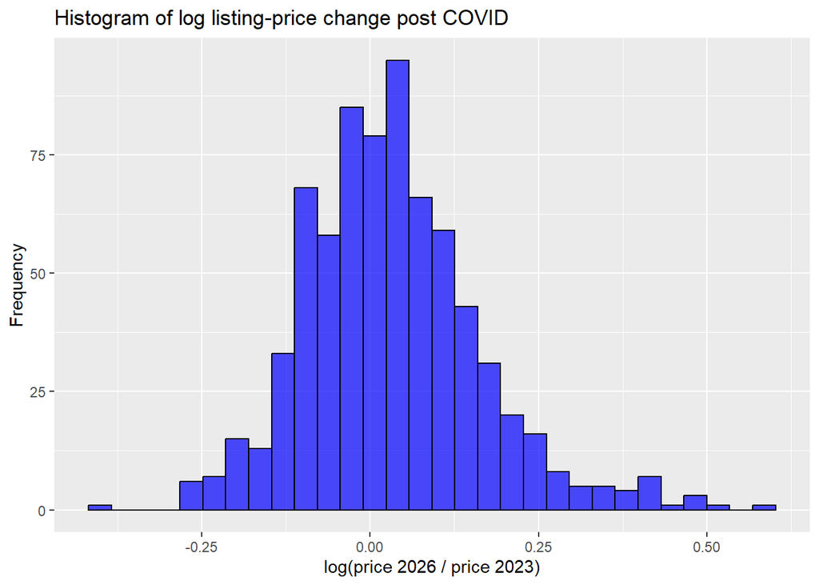

```r
ggplot(data = q1, aes(log_price_change)) +
  geom_histogram(bins = 30,
                 col = "black",
                 fill = "blue",
                 alpha = .7) + # opacity
  labs(x = "log(price 2026 / price 2023)", y = "Frequency") +
  labs(title = "Histogram of log listing-price change post COVID")
```

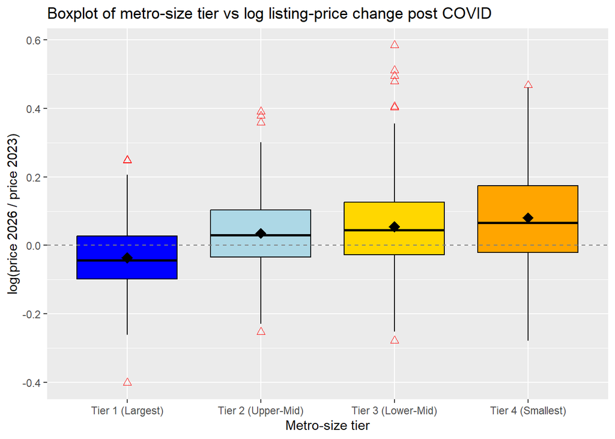

```r
ggplot(q1, aes(x = metro_size_group, y = log_price_change, fill = metro_size_group)) +
  geom_boxplot(colour = "black", outlier.colour = "red", outlier.shape = 2, outlier.size = 2) +
  stat_summary(fun = mean, geom = "point", shape = 18, size = 4, colour = "black") +
  geom_hline(yintercept = 0, linetype = "dashed", colour = "grey50") +
  scale_fill_manual(values = q1_colors) +
  labs(title = "Boxplot of metro-size tier vs log listing-price change post COVID",
       x = "Metro-size tier", y = "log(price 2026 / price 2023)") +
  theme(legend.position = "none")
```

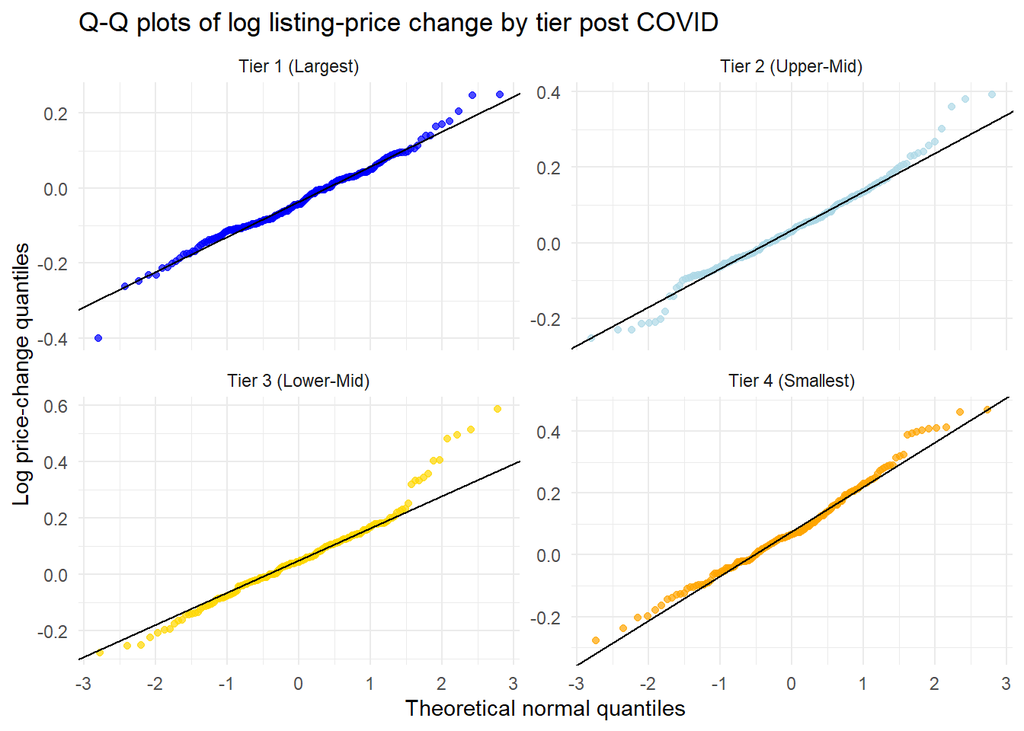

```r
q1_qq_plot <- ggplot(q1, aes(sample = log_price_change, color = metro_size_group)) +
  stat_qq(size = 1.5, alpha = 0.7) +
  stat_qq_line(color = "black") +
  facet_wrap(~ metro_size_group, ncol = 2, scales = "free_y") +
  scale_color_manual(values = q1_colors) +
  labs(title = "Q-Q plots of log listing-price change by tier post COVID",
       x = "Theoretical normal quantiles",
       y = "Log price-change quantiles") +
  theme_minimal(base_size = 11) +
  theme(legend.position = "none")

q1_qq_plot
```

```r
q1_summary <- q1 %>%
  dplyr::group_by(metro_size_group) %>%
  dplyr::summarise(
    n = dplyr::n(),
    mean_log_change = mean(log_price_change),
    median_log_change = median(log_price_change),
    sd_log_change = sd(log_price_change),
    avg_pct_change = 100 * (exp(mean(log_price_change)) - 1)
  )

xkabledply(as.data.frame(q1_summary), title = "Log listing-price change by metro-size tier")
```

Log listing-price change by metro-size tier

| metro_size_group | n | mean_log_change | median_log_change | sd_log_change | avg_pct_change |
| --- | --- | --- | --- | --- | --- |
| Tier 1 (Largest) | 195 | -0.0359 | -0.0432 | 0.0958 | -3.53 |
| Tier 2 (Upper-Mid) | 194 | 0.0353 | 0.0298 | 0.1096 | 3.59 |
| Tier 3 (Lower-Mid) | 182 | 0.0542 | 0.0439 | 0.1415 | 5.57 |
| Tier 4 (Smallest) | 159 | 0.0809 | 0.0653 | 0.1470 | 8.42 |

In the boxplot, black diamonds show the mean of each tier and the lines inside the boxes show the median. The Q-Q plots show the log price changes are roughly normal in all four tiers. Tiers 2 and 3 have a longer upper tail, meaning a few metros had unusually large price gains, but with this many metros per tier the ANOVA holds up well to mild non-normality. So we can conduct an ANOVA test on log listing-price change.

### Null Hypothesis Construction Metro-Size Tier

**Null Hypothesis** $H_0: \mu_1=\mu_2=\mu_3=\mu_4$ average log listing-price change is equal across all four metro-size tiers  
**Alternative Hypothesis** $H_1:$ at least one tier’s average log listing-price change is different  
**Alpha** $\alpha=0.05$

### ANOVA Hypothesis Testing Metro-Size Tier

```r
q1_anova <- aov(log_price_change ~ metro_size_group, data = q1)
q1_pval <- summary(q1_anova)[[1]][1, 5]
xkabledply(q1_anova, title = "Log Listing-Price Change and Metro-Size Tier ANOVA result summary")
```

Log Listing-Price Change and Metro-Size Tier ANOVA result summary

|  | Df | Sum Sq | Mean Sq | F value | Pr(>F) |
| --- | --- | --- | --- | --- | --- |
| metro_size_group | 3 | 1.37 | 0.4564 | 29.8 | 0 |
| Residuals | 726 | 11.14 | 0.0153 | NA | NA |

```r
# Mean log change per tier, converted to average % change.
q1_means <- tapply(q1$log_price_change, q1$metro_size_group, mean)
q1_pct <- 100 * (exp(q1_means) - 1)
round(q1_pct, 2)
```

```
##   Tier 1 (Largest) Tier 2 (Upper-Mid) Tier 3 (Lower-Mid)  Tier 4 (Smallest)
##              -3.53               3.59               5.57               8.42
```

```r
# Check: Welch's ANOVA does not assume the tiers have equal spreads.
q1_welch_pval <- oneway.test(log_price_change ~ metro_size_group, data = q1, var.equal = FALSE)$p.value
q1_welch_pval
```

```
## [1] 2.22e-20
```

### Analysis Metro-Size Tier

Our p-value is <0.001, which is below our $\alpha$ (0.05), so we reject our null hypothesis and have data that supports our alternative hypothesis that average log listing-price change is not equal across all four metro-size tiers.

Converted to percentages, Tier 4 (Smallest) had the largest average price change (8.4%) and Tier 1 (Largest) had the smallest (-3.5%). Because the tiers have different spreads, we also ran Welch’s ANOVA, which gives a p-value of <0.001 and leads to the same conclusion.

**Post-hoc Tukey Time for Metro-Size Tier**

```r
q1_tukey <- TukeyHSD(q1_anova)
q1_tukey
```

```
##   Tukey multiple comparisons of means
##     95% family-wise confidence level
##
## Fit: aov(formula = log_price_change ~ metro_size_group, data = q1)
##
## $metro_size_group
##                                         diff      lwr    upr p adj
## Tier 2 (Upper-Mid)-Tier 1 (Largest)   0.0712  0.03884 0.1035 0.000
## Tier 3 (Lower-Mid)-Tier 1 (Largest)   0.0901  0.05723 0.1230 0.000
## Tier 4 (Smallest)-Tier 1 (Largest)    0.1167  0.08266 0.1508 0.000
## Tier 3 (Lower-Mid)-Tier 2 (Upper-Mid) 0.0189 -0.01399 0.0518 0.450
## Tier 4 (Smallest)-Tier 2 (Upper-Mid)  0.0456  0.01144 0.0797 0.003
## Tier 4 (Smallest)-Tier 3 (Lower-Mid)  0.0266 -0.00798 0.0613 0.196
```

```r
q1_tukey_table <- as.data.frame(q1_tukey$metro_size_group)
q1_sig_pairs <- rownames(q1_tukey_table)[q1_tukey_table$`p adj` < 0.05]
```

Each row compares two tiers, and pairs with a `p adj` below 0.05 have significantly different average log price changes. Significantly different pairs: Tier 2 (Upper-Mid)-Tier 1 (Largest); Tier 3 (Lower-Mid)-Tier 1 (Largest); Tier 4 (Smallest)-Tier 1 (Largest); Tier 4 (Smallest)-Tier 2 (Upper-Mid).

## Question 2

**After COVID (from June 2023 to August 2026), were increases in pending ratios associated with changes in median listing prices across metro areas?**

**Pending Ratio:** The number of pending listings divided by the number of active listings. It measures the balance between supply (active listings) and demand (pending listings).  
- **Increase in Pending Ratio:** The market got tighter. Demand grew relative to supply, meaning buyers faced more competition and sellers gained more leverage.  
- **Decrease in Pending Ratio:** The market got looser. Supply grew relative to demand, meaning buyers gained more leverage and sellers faced more competition to sell.

We answer this two ways. An ANOVA compares the **size** of the average log price change between metros whose pending ratio increased and metros whose pending ratio decreased. A chi-square test compares the **direction**, meaning the share of metros whose listing price increased.

### EDA

Let’s first group each metro by the direction of its pending ratio and its listing price. A metro counts as “Increased” if its August 2026 value is higher than its June 2023 value, and “Decreased” otherwise, so “Decreased” also includes the few metros with no change.

```r
q2 <- subset(
  metro_endpoints,
  is.finite(log_price_change) &
  is.finite(pending_2023) &
  is.finite(pending_2026) &
  pending_2023 >= 0 &
  pending_2026 >= 0
)

stopifnot(nrow(q2) > 0)
stopifnot(anyDuplicated(q2$cbsa_code) == 0)

q2$pending_change <- q2$pending_2026 - q2$pending_2023

directions <- c("Increased", "Decreased")

q2$pending_group <- factor(
  ifelse(q2$pending_change > 0, "Increased", "Decreased"),
  levels = directions
)

q2$price_group <- factor(
  ifelse(q2$price_2026 > q2$price_2023, "Increased", "Decreased"),
  levels = directions
)

q2_colors <- c("Increased" = "#eb6834", "Decreased" = "#2a78d6")

table(q2$pending_group)
```

```
##
## Increased Decreased
##        81       647
```

```r
table(q2$price_group)
```

```
##
## Increased Decreased
##       414       314
```

Next, let’s look at the spread of log listing-price change in each pending-ratio group.

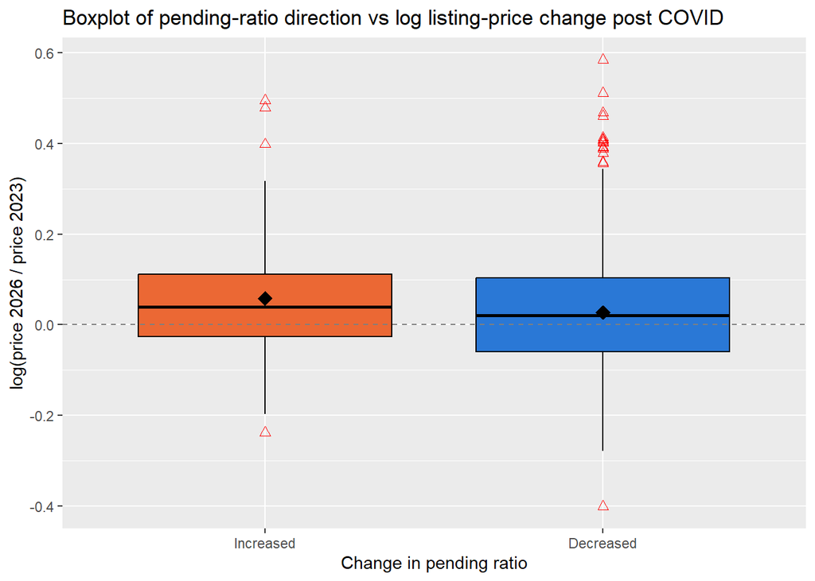

```r
ggplot(q2, aes(x = pending_group, y = log_price_change, fill = pending_group)) +
  geom_boxplot(colour = "black", outlier.colour = "red", outlier.shape = 2, outlier.size = 2) +
  stat_summary(fun = mean, geom = "point", shape = 18, size = 4, colour = "black") +
  geom_hline(yintercept = 0, linetype = "dashed", colour = "grey50") +
  scale_fill_manual(values = q2_colors) +
  labs(title = "Boxplot of pending-ratio direction vs log listing-price change post COVID",
       x = "Change in pending ratio", y = "log(price 2026 / price 2023)") +
  theme(legend.position = "none")
```

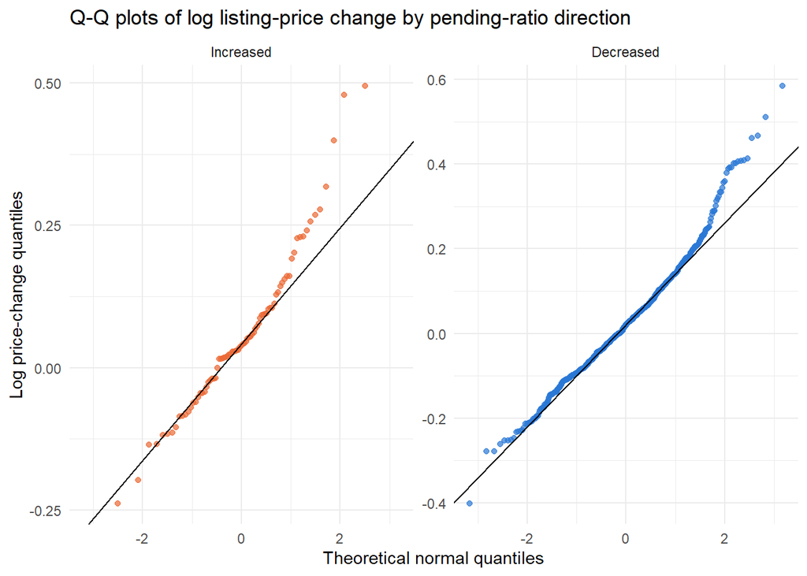

```r
q2_qq_plot <- ggplot(q2, aes(sample = log_price_change, color = pending_group)) +
  stat_qq(size = 1.5, alpha = 0.7) +
  stat_qq_line(color = "black") +
  facet_wrap(~ pending_group, ncol = 2, scales = "free_y") +
  scale_color_manual(values = q2_colors) +
  labs(title = "Q-Q plots of log listing-price change by pending-ratio direction",
       x = "Theoretical normal quantiles",
       y = "Log price-change quantiles") +
  theme_minimal(base_size = 11) +
  theme(legend.position = "none")

q2_qq_plot
```

Finally, let’s count how many metros fall into each combination of pending-ratio direction and listing-price direction, and show each group’s split as a 100% stacked bar.

```r
q2_table <- table(
  q2$pending_group,
  q2$price_group,
  dnn = c("Pending ratio", "Listing price")
)

addmargins(q2_table)
```

```
##              Listing price
## Pending ratio Increased Decreased Sum
##     Increased        55        26  81
##     Decreased       359       288 647
##     Sum             414       314 728
```

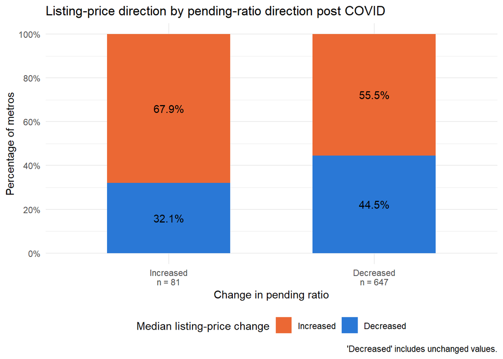

```r
q2_prop <- 100 * prop.table(q2_table, margin = 1)

q2_bar <- as.data.frame(q2_prop)
names(q2_bar) <- c("pending_group", "price_group", "percent")
q2_bar$label <- ifelse(q2_bar$percent > 0, paste0(round(q2_bar$percent, 1), "%"), "")

q2_axis_labels <- paste0(directions, "\nn = ", rowSums(q2_table))

q2_plot <- ggplot(q2_bar, aes(pending_group, percent, fill = price_group)) +
  geom_bar(stat = "identity", width = 0.6) +
  geom_text(aes(label = label), position = position_stack(vjust = 0.5)) +
  scale_fill_manual(values = q2_colors, name = "Median listing-price change") +
  scale_x_discrete(labels = q2_axis_labels) +
  scale_y_continuous(breaks = seq(0, 100, 20), labels = paste0(seq(0, 100, 20), "%")) +
  labs(title = "Listing-price direction by pending-ratio direction post COVID",
       x = "Change in pending ratio",
       y = "Percentage of metros",
       caption = "'Decreased' includes unchanged values.") +
  theme_minimal() +
  theme(legend.position = "bottom")

q2_plot
```

### Null Hypothesis Construction Pending-Ratio Direction

**Null Hypothesis** $H_0: \mu_{increased}=\mu_{decreased}$ average log listing-price change is equal for metros whose pending ratio increased and metros whose pending ratio decreased  
**Alternative Hypothesis** $H_1: \mu_{increased}\neq\mu_{decreased}$ average log listing-price change is different between the two groups  
**Alpha** $\alpha=0.05$

### ANOVA Hypothesis Testing Pending-Ratio Direction

```r
q2_anova <- aov(log_price_change ~ pending_group, data = q2)
q2_pval <- summary(q2_anova)[[1]][1, 5]
xkabledply(q2_anova, title = "Log Listing-Price Change and Pending-Ratio Direction ANOVA result summary")
```

Log Listing-Price Change and Pending-Ratio Direction ANOVA result summary

|  | Df | Sum Sq | Mean Sq | F value | Pr(>F) |
| --- | --- | --- | --- | --- | --- |
| pending_group | 1 | 0.0693 | 0.0693 | 4.05 | 0.0446 |
| Residuals | 726 | 12.4331 | 0.0171 | NA | NA |

```r
# Mean log change per group, converted to average % change.
q2_means <- tapply(q2$log_price_change, q2$pending_group, mean)
q2_pct <- 100 * (exp(q2_means) - 1)
round(q2_pct, 2)
```

```
## Increased Decreased
##      6.01      2.78
```

```r
# Check: Welch's ANOVA does not assume the groups have equal spreads.
q2_welch_pval <- oneway.test(log_price_change ~ pending_group, data = q2, var.equal = FALSE)$p.value
q2_welch_pval
```

```
## [1] 0.0554
```

### Analysis Pending-Ratio Direction

Our p-value is 0.0446, which is below our $\alpha$ (0.05), so we reject our null hypothesis and have data that supports our alternative hypothesis that average log listing-price change is different between metros whose pending ratio increased and metros whose pending ratio decreased.

Converted to percentages, metros whose pending ratio increased had an average price change of 6%, compared with 2.8% for metros whose pending ratio decreased. Welch’s ANOVA gives a p-value of 0.0554 and leads to a different conclusion, so this result should be interpreted with caution. With only two groups, no post-hoc Tukey test is needed.

### Null Hypothesis Construction Pending-Ratio Direction

**Null Hypothesis** $H_0:$ pending-ratio direction and listing-price direction are independent  
**Alternative Hypothesis** $H_1:$ pending-ratio direction and listing-price direction are NOT independent  
**Alpha** $\alpha=0.05$

### $\chi^2$ Hypothesis Testing Pending-Ratio Direction

```r
# Expected counts if the two directions were independent.
q2_expected <- outer(rowSums(q2_table), colSums(q2_table)) / sum(q2_table)
dimnames(q2_expected) <- dimnames(q2_table)
round(q2_expected, 2)
```

```
##              Listing price
## Pending ratio Increased Decreased
##     Increased      46.1      34.9
##     Decreased     367.9     279.1
```

```r
# Classroom rule: every expected count must be at least 5.
stopifnot(all(q2_expected >= 5))

q2_chi <- chisq.test(q2_table, correct = FALSE)
q2_chi_pval <- q2_chi$p.value
q2_chi
```

```
##
##  Pearson's Chi-squared test
##
## data:  q2_table
## X-squared = 5, df = 1, p-value = 0.03
```

### Analysis Pending-Ratio Direction

All expected counts are at least 5, so the chi-square test is valid. Our p-value is 0.0334, which is below our $\alpha$ (0.05), so we reject our null hypothesis and have data that supports our alternative hypothesis that pending-ratio direction and listing-price direction are associated.

67.9% of metros whose pending ratio increased saw their median listing price rise, compared with 55.5% of metros whose pending ratio decreased.

Both tests assume each metro is an independent observation, and they show association, not cause and effect.

## Question 3a

**After COVID (from June 2023 to August 2026) is the average number of price reduction/increase share the same across different metro areas, across states?**  
**price_increased_share:** The percent of houses that had price increases in that metro area  
**price_reduced_share:** The percent of houses that had price reductions in that metro area

### EDA

It’s important to see the variation in our data before constructing our hypotheses. So let’s plot the variation in price increase and reduce share.

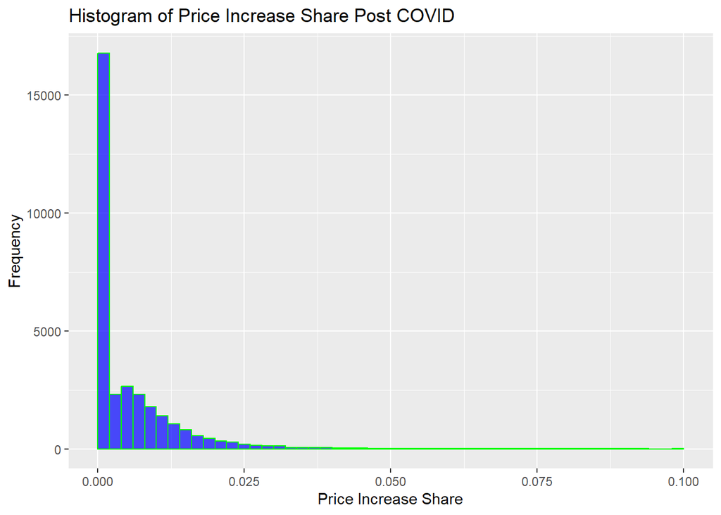

```r
ggplot(data=quality_housing, aes(price_increased_share)) +
  geom_histogram(breaks=seq(0, 0.1, by = 0.002),
                 col="green",
                 fill="blue",
                 alpha = .7) + # opacity
  labs(x="Price Increase Share", y="Frequency") +
  labs(title="Histogram of Price Increase Share Post COVID")
```

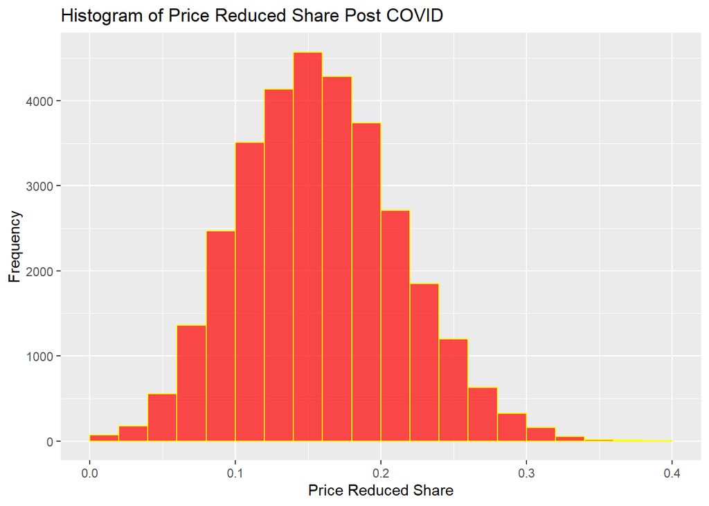

```r
ggplot(data=quality_housing, aes(price_reduced_share)) +
  geom_histogram(breaks=seq(0, 0.4, by = 0.02),
                 col="yellow",
                 fill="red",
                 alpha = .7) + # opacity
  labs(x="Price Reduced Share", y="Frequency") +
  labs(title="Histogram of Price Reduced Share Post COVID")
```

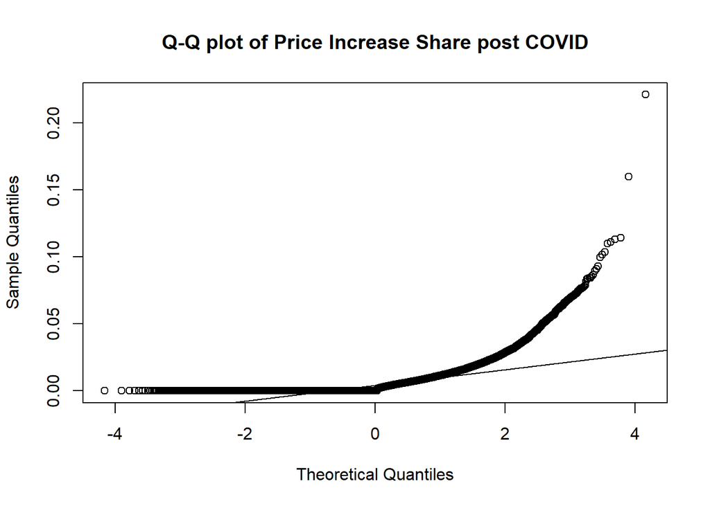

```r
qqnorm(quality_housing$price_increased_share, main="Q-Q plot of Price Increase Share post COVID")
qqline(quality_housing$price_increased_share)
```

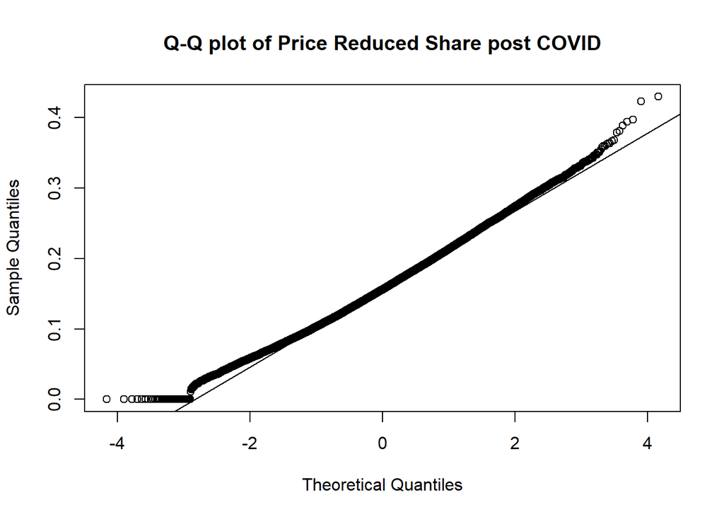

```r
qqnorm(quality_housing$price_reduced_share, main="Q-Q plot of Price Reduced Share post COVID")
qqline(quality_housing$price_reduced_share)
```

Reductions looks good but price_increase_shares is right skewed so lets normalize our data then plot again.

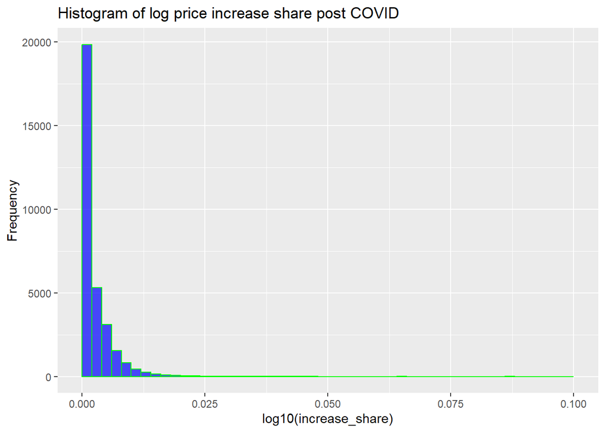

```r
#log transform our data
log_housing = quality_housing
log_housing$log_inc_share = log10(log_housing$price_increased_share + 1)

ggplot(data=log_housing, aes(log_inc_share)) +
  geom_histogram(breaks=seq(0, 0.1, by = 0.002),
                 col="green",
                 fill="blue",
                 alpha = .7) + # opacity
  labs(x="log10(increase_share)", y="Frequency") +
  labs(title="Histogram of log price increase share post COVID")
```

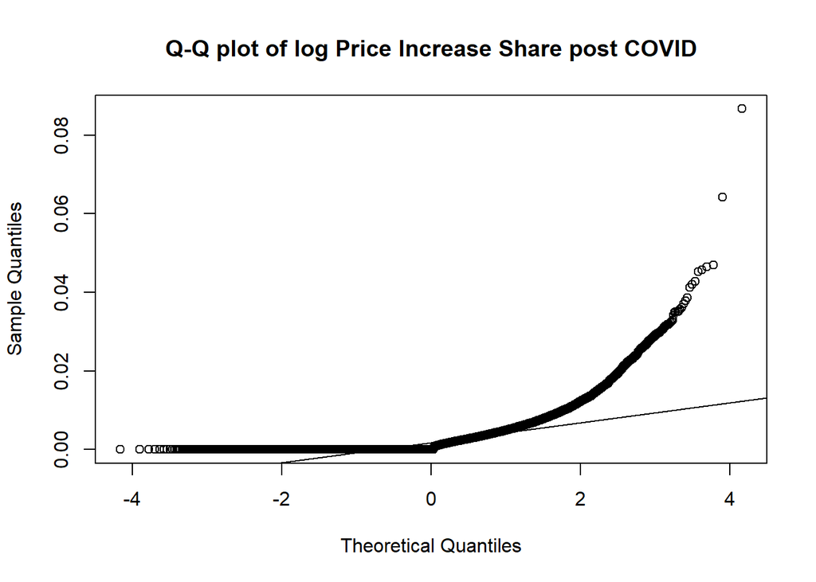

```r
qqnorm(log_housing$log_inc_share, main="Q-Q plot of log Price Increase Share post COVID")
qqline(log_housing$log_inc_share)
```

Our reduction histogram looks normal but the increase share even after normalizing is still skewed due to the large amount of 0s so we cannot conduct an ANOVA test on price increases. So let’s modify our question:

**After COVID (from June 2023 to August 2026) is the average number of price reductions the same across different metro areas, across states?**  
**price_reduced_share:** The percent of houses that had price reductions in that metro area  
**Household Rank:** a rank assigned to a metro area the higher number of household the higher the rank (1 being highest)

### Null Hypothesis Construction Household Rank

**Null Hypothesis** $H_0: \mu_1=\mu_2=...=\mu_{924}=\mu_{925}$ average price reduction share is equal across all household ranks  
**Alternative Hypothesis** $H_1:$ The 925 mean values are NOT all equal  
**Alpha** $\alpha=0.05$

### ANOVA Hypothesis Testing Household Rank

```r
anovaRank = aov(price_reduced_share ~ HouseholdRank, data = log_housing)
red_rank_pval = summary(anovaRank)[[1]][1,5]
xkabledply(anovaRank, title = "Price Reduction Share and Household Rank ANOVA result summary")
```

Price Reduction Share and Household Rank ANOVA result summary

|  | Df | Sum Sq | Mean Sq | F value | Pr(>F) |
| --- | --- | --- | --- | --- | --- |
| HouseholdRank | 924 | 41.8 | 0.0453 | 26.2 | 0 |
| Residuals | 30902 | 53.3 | 0.0017 | NA | NA |

### Analysis Household Rank

Since our P-value is 0 well below our $\alpha$ (0.05) we reject our null hypothesis and have data that supports our alternative hypothesis that all average reduction share are not equal across all house ranks.

**Post-hoc Tukey Time for Household Rank**

```r
tukeyAoVRank = TukeyHSD(anovaRank)
head(tukeyAoVRank$HouseholdRank , n=100)
```

```
##            diff      lwr    upr    p adj
## 2-1    0.045231 -0.00353 0.0940 2.19e-01
## 3-1    0.044364 -0.00440 0.0931 2.95e-01
## 4-1    0.163049  0.11429 0.2118 0.00e+00
## 5-1    0.106779  0.05802 0.1555 0.00e+00
## 6-1    0.085962  0.03415 0.1378 1.15e-11
## 7-1    0.057246  0.00848 0.1060 4.31e-04
## 8-1    0.123236  0.07447 0.1720 0.00e+00
## 9-1    0.053885  0.00512 0.1026 3.34e-03
## 10-1   0.186590  0.13783 0.2354 0.00e+00
## 11-1   0.058787  0.01003 0.1075 1.59e-04
## 12-1   0.064859  0.01610 0.1136 2.25e-06
## 13-1   0.041215 -0.00892 0.0913 7.92e-01
## 14-1   0.074036  0.02527 0.1228 1.53e-09
## 15-1   0.078110  0.02935 0.1269 5.31e-11
## 16-1   0.060744  0.01198 0.1095 4.25e-05
## 17-1   0.178759  0.13000 0.2275 0.00e+00
## 18-1   0.170154  0.12139 0.2189 0.00e+00
## 19-1   0.077918  0.02916 0.1267 6.13e-11
## 20-1   0.124433  0.07567 0.1732 0.00e+00
## 21-1   0.067515  0.01875 0.1163 3.01e-07
## 22-1   0.136226  0.08746 0.1850 0.00e+00
## 23-1   0.073033  0.02427 0.1218 3.54e-09
## 24-1   0.086038  0.03728 0.1348 1.13e-11
## 25-1   0.165854  0.11709 0.2146 0.00e+00
## 26-1   0.180567  0.13149 0.2296 0.00e+00
## 27-1   0.158779  0.11002 0.2075 0.00e+00
## 28-1   0.069551  0.02079 0.1183 6.10e-08
## 29-1   0.115746  0.06698 0.1645 0.00e+00
## 30-1   0.074356  0.02559 0.1231 1.17e-09
## 31-1   0.066653  0.01724 0.1161 1.14e-06
## 32-1   0.093618  0.04486 0.1424 7.93e-12
## 33-1   0.129148  0.08007 0.1782 0.00e+00
## 34-1   0.148364  0.09960 0.1971 0.00e+00
## 35-1   0.115877  0.06680 0.1650 0.00e+00
## 36-1   0.161910  0.11315 0.2107 0.00e+00
## 37-1   0.097021  0.04826 0.1458 9.35e-12
## 38-1   0.028562 -0.02020 0.0773 1.00e+00
## 39-1   0.027015 -0.02175 0.0758 1.00e+00
## 40-1   0.047318 -0.00144 0.0961 9.58e-02
```

[output cut: 46 more lines]

```
## 87-1   0.062138  0.01306 0.1112 2.14e-05
## 88-1   0.090885  0.04147 0.1403 7.45e-12
## 89-1   0.031428 -0.01733 0.0802 1.00e+00
## 90-1   0.082423  0.03366 0.1312 8.02e-12
## 91-1   0.073524  0.02444 0.1226 3.51e-09
## 92-1   0.033694 -0.01767 0.0851 1.00e+00
## 93-1   0.051522  0.00244 0.1006 1.49e-02
## 94-1   0.065805  0.01704 0.1146 1.11e-06
## 95-1   0.100528  0.05177 0.1493 8.97e-12
## 96-1   0.127903  0.07914 0.1767 0.00e+00
## 97-1   0.094502  0.04509 0.1439 8.23e-12
## 98-1   0.087867  0.03911 0.1366 9.20e-12
## 99-1   0.127397  0.07864 0.1762 0.00e+00
## 100-1  0.011003 -0.03808 0.0601 1.00e+00
## 101-1  0.077569  0.02881 0.1263 8.04e-11
```

```r
tukeyRankdf = data.frame(tukeyAoVRank$HouseholdRank)
problem_rank_pairs = subset(tukeyRankdf, p.adj<0.05)  # failed
passed_rank_pairs = subset(tukeyRankdf, p.adj>=0.05)  # passed
```

Of all the 427350 rows in the Tukey test 131817 failed and 295533 passed. That’s 30.845 percent of the pairs failing while 69.155 percent passed. There was also 11446 zero pairs. These problem pairs along with the quick view from our box plotted data confirmed that our results in the ANOVA test having us reject our null hypothesis, but is it the same across states?

### Null Hypothesis Construction State

**Null Hypothesis** $H_0: \mu_1=\mu_2=...=\mu_{50}=\mu_{51}$ average price reduction share is equal across all sates (and DC)  
**Alternative Hypothesis** $H_1:$ The 51 mean values are NOT all equal  
**Alpha** $\alpha=0.05$

### ANOVA Hypothesis Testing State

```r
anovaState = aov(price_reduced_share ~ state_ss, data = log_housing)
red_state_pval = summary(anovaState)[[1]][1,5]
xkabledply(anovaState, title = "Price Reduction Share and State ANOVA result summary")
```

Price Reduction Share and State ANOVA result summary

|  | Df | Sum Sq | Mean Sq | F value | Pr(>F) |
| --- | --- | --- | --- | --- | --- |
| state_ss | 50 | 17.9 | 0.3588 | 148 | 0 |
| Residuals | 31776 | 77.2 | 0.0024 | NA | NA |

### Analysis State

Since our P-value is 0 well below our $\alpha$ (0.05) we reject our null hypothesis and have data that supports our alternative hypothesis that all average reduction shares are not equal across all states (including DC).

**Post-hoc Tukey Time for State**

```r
tukeyAoVState = TukeyHSD(anovaState)
tukeyAoVState
```

```
##   Tukey multiple comparisons of means
##     95% family-wise confidence level
##
## Fit: aov(formula = price_reduced_share ~ state_ss, data = log_housing)
##
## $state_ss
##            diff       lwr       upr p adj
## AL-AK  3.11e-02  1.28e-02  4.94e-02 0.000
## AR-AK  1.04e-02 -8.32e-03  2.91e-02 0.993
## AZ-AK  4.84e-02  2.89e-02  6.79e-02 0.000
## CA-AK  1.98e-02  1.91e-03  3.77e-02 0.009
## CO-AK  4.50e-02  2.61e-02  6.38e-02 0.000
## CT-AK -4.14e-02 -6.24e-02 -2.04e-02 0.000
## DC-AK -9.36e-04 -3.68e-02  3.49e-02 1.000
## DE-AK  9.86e-03 -1.82e-02  3.79e-02 1.000
## FL-AK  7.05e-02  5.24e-02  8.85e-02 0.000
## GA-AK  2.71e-02  9.22e-03  4.50e-02 0.000
## HI-AK  9.20e-04 -2.43e-02  2.61e-02 1.000
## IA-AK  1.89e-02  4.63e-04  3.74e-02 0.035
## ID-AK  3.46e-02  1.53e-02  5.38e-02 0.000
## IL-AK  8.95e-03 -9.24e-03  2.71e-02 0.999
## IN-AK  5.00e-02  3.21e-02  6.79e-02 0.000
## KS-AK  1.31e-02 -5.87e-03  3.21e-02 0.824
## KY-AK  4.27e-02  2.43e-02  6.12e-02 0.000
## LA-AK  3.94e-02  2.07e-02  5.82e-02 0.000
## MA-AK -3.17e-03 -2.33e-02  1.70e-02 1.000
## MD-AK  1.51e-02 -5.42e-03  3.57e-02 0.686
## ME-AK  3.86e-02  1.50e-02  6.22e-02 0.000
## MI-AK  1.82e-02  2.77e-04  3.62e-02 0.040
## MN-AK  6.84e-03 -1.16e-02  2.52e-02 1.000
## MO-AK  1.93e-02  9.88e-04  3.75e-02 0.022
## MS-AK  8.44e-03 -1.03e-02  2.71e-02 1.000
## MT-AK  1.86e-02 -2.54e-03  3.98e-02 0.225
## NC-AK  3.20e-02  1.42e-02  4.98e-02 0.000
## ND-AK -1.36e-02 -3.45e-02  7.31e-03 0.912
## NE-AK  4.38e-03 -1.52e-02  2.40e-02 1.000
## NH-AK -1.44e-02 -3.65e-02  7.80e-03 0.917
## NJ-AK -2.13e-02 -4.62e-02  3.61e-03 0.288
## NM-AK -4.25e-03 -2.32e-02  1.46e-02 1.000
## NV-AK  3.30e-02  1.22e-02  5.37e-02 0.000
```

[output cut: 1227 more lines]

```
## VT-VA -3.46e-02 -5.24e-02 -1.69e-02 0.000
## WA-VA  2.20e-02  1.03e-02  3.38e-02 0.000
## WI-VA -2.49e-02 -3.62e-02 -1.36e-02 0.000
## WV-VA  6.61e-05 -1.36e-02  1.38e-02 1.000
## WY-VA -1.33e-02 -2.77e-02  1.12e-03 0.139
## WA-VT  5.67e-02  3.99e-02  7.34e-02 0.000
## WI-VT  9.70e-03 -6.76e-03  2.62e-02 0.980
## WV-VT  3.47e-02  1.65e-02  5.29e-02 0.000
## WY-VT  2.13e-02  2.62e-03  4.00e-02 0.005
## WI-WA -4.69e-02 -5.67e-02 -3.72e-02 0.000
## WV-WA -2.20e-02 -3.44e-02 -9.58e-03 0.000
## WY-WA -3.53e-02 -4.85e-02 -2.22e-02 0.000
## WV-WI  2.50e-02  1.30e-02  3.70e-02 0.000
## WY-WI  1.16e-02 -1.17e-03  2.44e-02 0.163
## WY-WV -1.33e-02 -2.83e-02  1.59e-03 0.194
```

```r
tukeyStatedf = data.frame(tukeyAoVState$state_ss)
problem_state_pairs = subset(tukeyStatedf, p.adj<0.05)  # failed
passed_state_pairs = subset(tukeyStatedf, p.adj>=0.05)  # passed
```

Of all the 1275 rows in the Tukey test 897 failed or 70.353 percent of the pairs failed. While 29.647 percent passed. There was also 356 zero pairs. Within these pairs multiple states are vastly different with others leading to our failed ANOVA test.

## Question 3b

```r
quality_housing$price_increases = ifelse(quality_housing$price_increased_share == 0, 0, 1)
quality_housing[,51] = as.factor(quality_housing[,51])
```

### EDA

[figure not shown]

```r
ggplot(quality_housing, aes(fill=price_increases, y=1, x=HouseholdRank)) +
    geom_bar(position="stack", stat="identity") +
    geom_col(width = 0.5) +

    labs(y= "Number of Increases Vs no Increases Per State",
          title="Ratio of Ranks with Price Increases Vs Didn't")
```

Though hard to see there is a general trend that the higher the HouseholdRank the more increases giving us a hint that the test may fail.

### Null Hypothesis Construction Household Rank

**Null Hypothesis** $H_0:$ price increases and metro area are independent  
**Alternative Hypothesis** $H_1:$ price increases and metro area are NOT independent  
**Alpha** $\alpha=0.05$

Now lets create contingency tables for price_increases verses Household rank.

```r
contableRank = table(quality_housing$price_increases, quality_housing$HouseholdRank )
xkabledply(contableRank, title="Contingency table for price_increases vs HouseholdRank")
```

Contingency table for price_increases vs HouseholdRank

|  | 1 | 2 | 3 | 4 | 5 | 6 | 7 | 8 | 9 | 10 | 11 | 12 | 13 | 14 | 15 | 16 | 17 | 18 | 19 | 20 | 21 | 22 | 23 | 24 | 25 | 26 | 27 | 28 | 29 | … |
| --- | --- | --- | --- | --- | --- | --- | --- | --- | --- | --- | --- | --- | --- | --- | --- | --- | --- | --- | --- | --- | --- | --- | --- | --- | --- | --- | --- | --- | --- | --- |
| 0 | 0 | 0 | 0 | 0 | 0 | 0 | 0 | 0 | 0 | 0 | 0 | 0 | 0 | 0 | 0 | 0 | 0 | 0 | 0 | 0 | 0 | 0 | 0 | 0 | 0 | 0 | 0 | 0 | 0 | … |
| 1 | 39 | 39 | 39 | 39 | 39 | 31 | 39 | 39 | 39 | 39 | 39 | 39 | 35 | 39 | 39 | 39 | 39 | 39 | 39 | 39 | 39 | 39 | 39 | 39 | 39 | 38 | 39 | 39 | 39 | … |

### $\chi^2$ Hypothesis Testing Household Rank

```r
chitestRank = chisq.test(contableRank)
chitestRank
```

```
##
##  Pearson's Chi-squared test
##
## data:  contableRank
## X-squared = 20049, df = 924, p-value <2e-16
```

### Analysis Rank

Since <2e-16 is less than our $\alpha$ we reject our null hypothesis and have data that supports our alternative hypothesis that price increases and metro area are NOT independent. Now is it the same across states?

### EDA

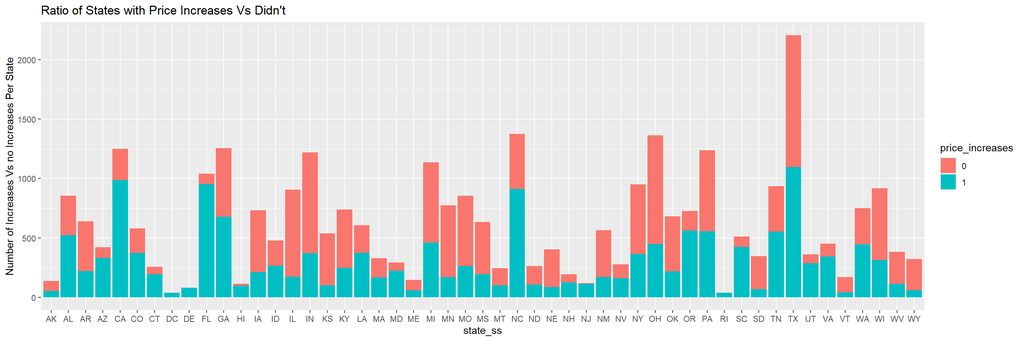

```r
ggplot(quality_housing, aes(fill=price_increases, y=1, x=state_ss)) +
    geom_bar(position="stack", stat="identity") +
    geom_col(width = 0.5) +
    labs(y= "Number of Increases Vs no Increases Per State",
          title="Ratio of States with Price Increases Vs Didn't")
```

This graph shows that the number of increases vary across multiple states but smaller states like Delaware and Rhode Island also have a small number of increases while states like Texas and New York are much larger hinting that our test may fail.

### Null Hypothesis Construction State

**Null Hypothesis** $H_0:$ price increases and state are independent  
**Alternative Hypothesis** $H_1:$ price increases and state are NOT independent  
**Alpha** $\alpha=0.05$

```r
contableState = table(quality_housing$price_increases, quality_housing$state_ss)
xkabledply(contableState, title="Contingency table for price_increases vs state_ss")
```

Contingency table for price_increases vs state_ss

|  | AK | AL | AR | AZ | CA | CO | CT | DC | DE | FL | GA | HI | IA | ID | IL | IN | KS | KY | LA | MA | MD | ME | MI | MN | MO | MS | MT | NC | ND | … |
| --- | --- | --- | --- | --- | --- | --- | --- | --- | --- | --- | --- | --- | --- | --- | --- | --- | --- | --- | --- | --- | --- | --- | --- | --- | --- | --- | --- | --- | --- | --- |
| 0 | 83 | 333 | 418 | 88 | 263 | 206 | 64 | 0 | 0 | 88 | 579 | 15 | 520 | 213 | 734 | 850 | 437 | 491 | 233 | 162 | 68 | 88 | 676 | 605 | 594 | 439 | 145 | 464 | 157 | … |
| 1 | 52 | 521 | 220 | 332 | 986 | 374 | 192 | 39 | 78 | 953 | 677 | 97 | 211 | 265 | 173 | 371 | 100 | 247 | 374 | 166 | 223 | 57 | 459 | 170 | 262 | 193 | 99 | 913 | 105 | … |

This table shows that not all states have the same number of increases per state (since there are different numbers of metro areas per state) leading to more variation as well.

### $\chi^2$ Hypothesis Testing State

```r
chitestState = chisq.test(contableState)
chitestState
```

```
##
##  Pearson's Chi-squared test
##
## data:  contableState
## X-squared = 5332, df = 50, p-value <2e-16
```

### Analysis State

Since <2e-16 is less than our $\alpha$ we reject our null hypothesis and have data that supports our alternative hypothesis that price increases and state are NOT independent.

## Question 4

**After COVID (from June 2023 to August 2026) does the average amount of total listings in a metro area fluctuate during the year? Is there an increase during important times (Ex. start of school/summer)?**  
**total_listing_count:** the total amount of listings in that metro area per month

### EDA

Let’s first look at the spread of number of total listings (quantitative).

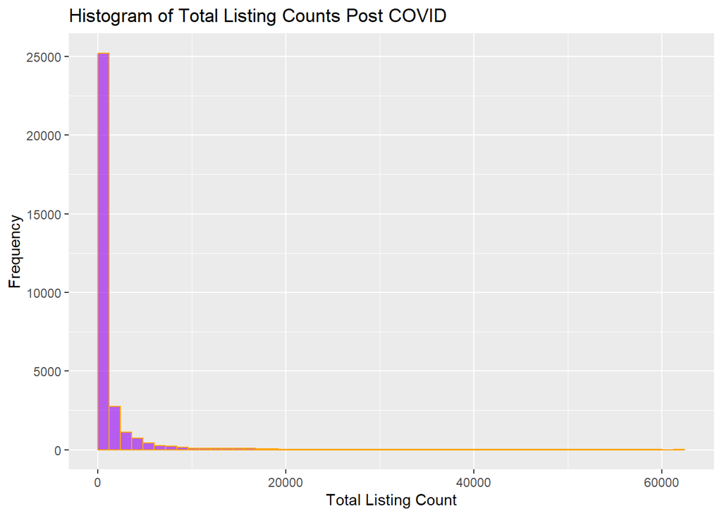

```r
ggplot(data=quality_housing, aes(total_listing_count)) +
  geom_histogram(breaks=seq(0, 63000, by = 1200),
                 col="orange",
                 fill="purple",
                 alpha = .7) + # opacity
  labs(x="Total Listing Count", y="Frequency") +
  labs(title="Histogram of Total Listing Counts Post COVID")
```

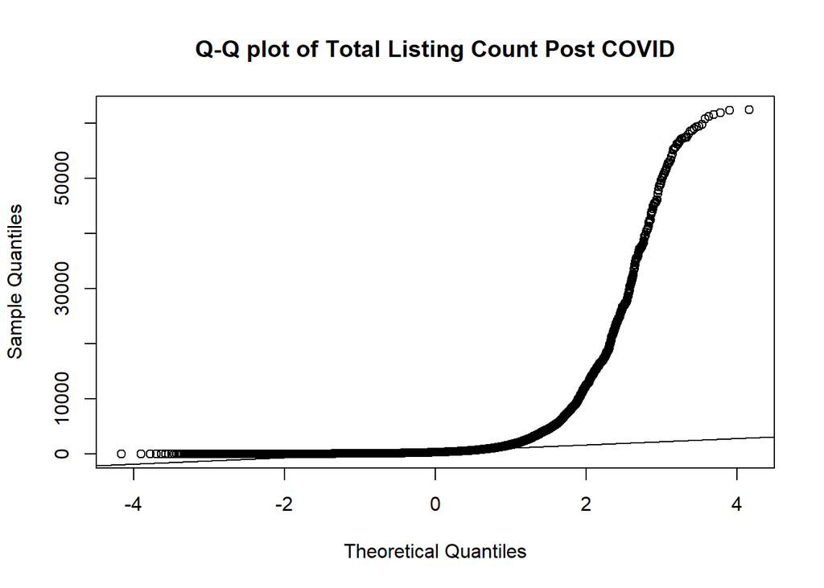

```r
qqnorm(quality_housing$total_listing_count, main="Q-Q plot of Total Listing Count Post COVID")
qqline(quality_housing$total_listing_count)
```

Skewed once again let’s normalize and re-plot.

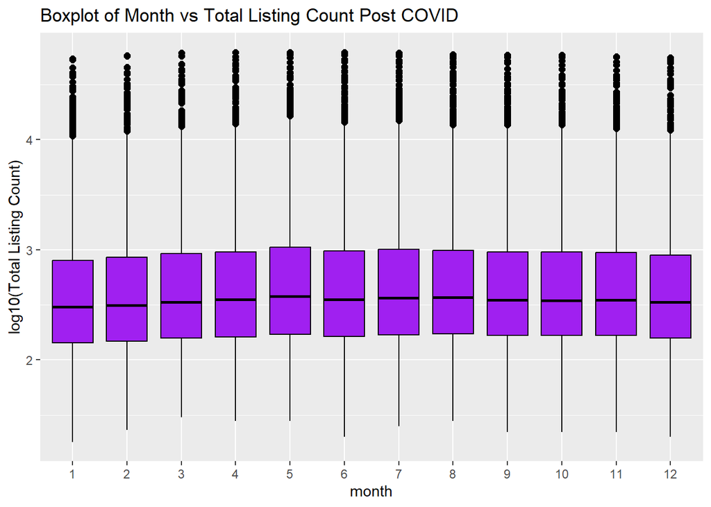

```r
# log transform the data
log_housing$log_list_count = log10(log_housing$total_listing_count + 1)

ggplot(log_housing, aes(x = month_mm, y = log_list_count)) +
  geom_boxplot() +
  geom_boxplot( colour="black", fill="purple", outlier.colour="black", outlier.size=2) +
  labs(title="Boxplot of Month vs Total Listing Count Post COVID", x="month", y = "log10(Total Listing Count)")
```

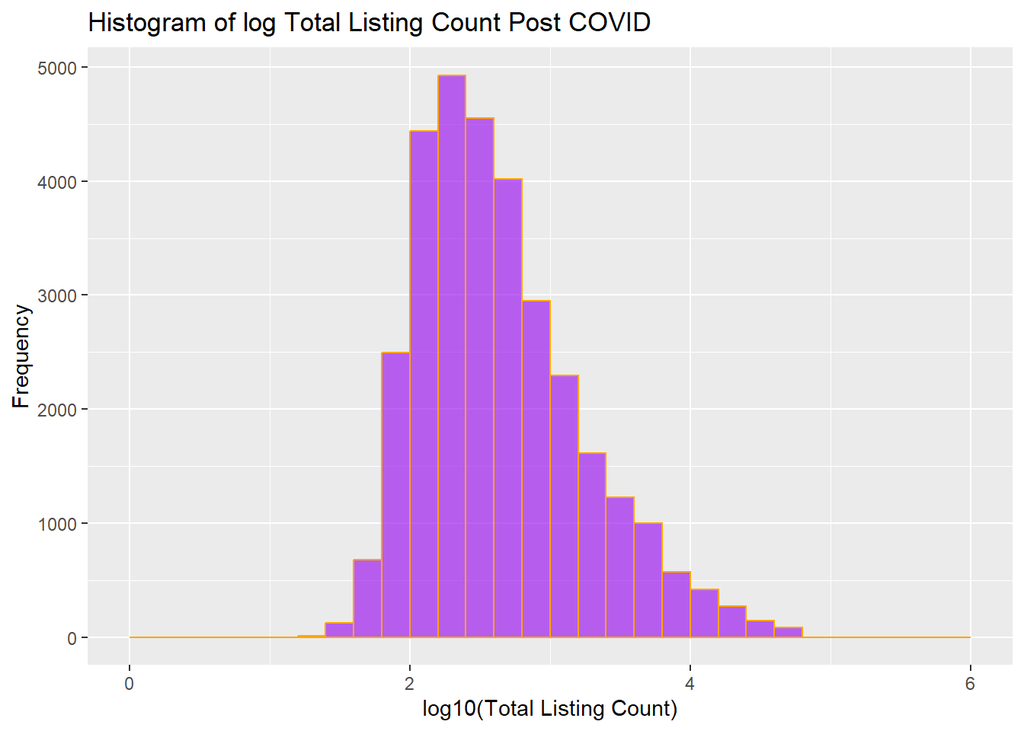

```r
ggplot(data=log_housing, aes(log_list_count)) +
  geom_histogram(breaks=seq(0, 6, by = 0.2),
                 col="orange",
                 fill="purple",
                 alpha = .7) + # opacity
  labs(x="log10(Total Listing Count)", y="Frequency") +
  labs(title="Histogram of log Total Listing Count Post COVID")
```

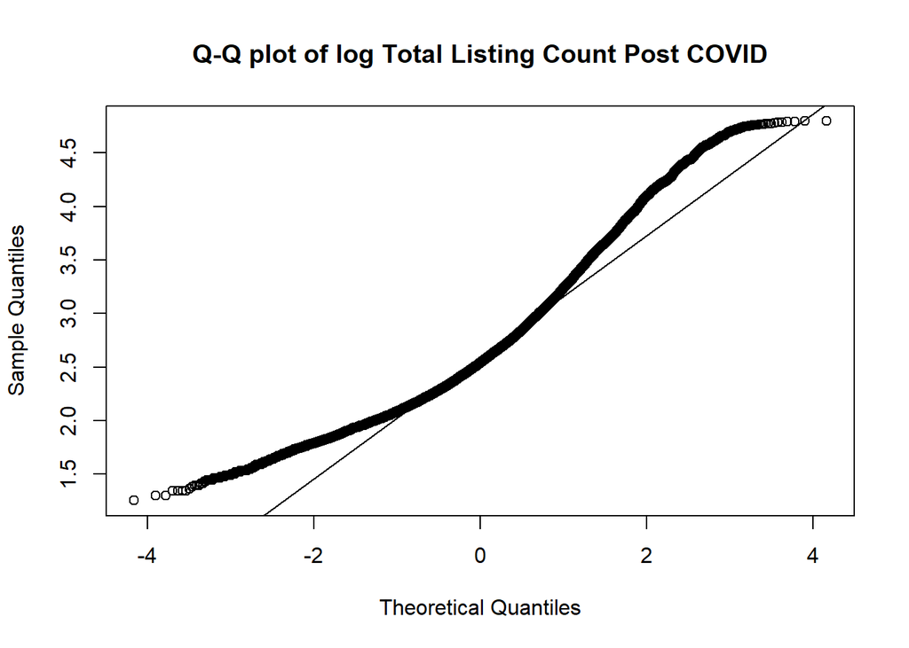

```r
qqnorm(log_housing$log_list_count, main="Q-Q plot of log Total Listing Count Post COVID")
qqline(log_housing$log_list_count)
```

From the box plots the variability is pretty even among all 12 months (possibly excluding months 1,2, and 12) so the test may fail.

### Null Hypothesis Construction Total Listings

**Null Hypothesis** $H_0: \mu_1=\mu_2=...=\mu_{11}=\mu_{12}$ average total listing count is equal across all 12 months  
**Alternative Hypothesis** $H_1:$ The 12 mean values are NOT all equal  
**Alpha** $\alpha=0.05$

### ANOVA Hypothesis Testing Total Listings

```r
anovaLogList = aov(log_list_count ~ month_mm, data = log_housing)
log_listing_pval = summary(anovaLogList)[[1]][1,5]
xkabledply(anovaLogList, title = "log Total Listing Count and Month ANOVA result summary")
```

log Total Listing Count and Month ANOVA result summary

|  | Df | Sum Sq | Mean Sq | F value | Pr(>F) |
| --- | --- | --- | --- | --- | --- |
| month_mm | 11 | 22.1 | 2.012 | 5.93 | 0 |
| Residuals | 31815 | 10789.2 | 0.339 | NA | NA |

### Analysis Total Listings

Since our p-value is 9.8e-10 well below our $\alpha$ (0.05) we reject our null hypothesis and have data that supports our alternative hypothesis that the average total listing count is not equal across all 12 months.

**Post-hoc Tukey Time for Total Listings**

```r
tukeyAoVList = TukeyHSD(anovaLogList)
tukeyAoVList
```

```
##   Tukey multiple comparisons of means
##     95% family-wise confidence level
##
## Fit: aov(formula = log_list_count ~ month_mm, data = log_housing)
##
## $month_mm
##            diff      lwr     upr p adj
## 2-1    0.019045 -0.03585 0.07394 0.993
## 3-1    0.050685 -0.00434 0.10571 0.105
## 4-1    0.068747  0.01400 0.12349 0.002
## 5-1    0.096771  0.04201 0.15153 0.000
## 6-1    0.074354  0.02330 0.12540 0.000
## 7-1    0.084643  0.03368 0.13560 0.000
## 8-1    0.085969  0.03518 0.13675 0.000
## 9-1    0.068581  0.01447 0.12269 0.002
## 10-1   0.068960  0.01469 0.12323 0.002
## 11-1   0.066352  0.01204 0.12066 0.004
## 12-1   0.044572 -0.01038 0.09953 0.252
## 3-2    0.031640 -0.02355 0.08683 0.776
## 4-2    0.049703 -0.00520 0.10461 0.121
## 5-2    0.077727  0.02281 0.13265 0.000
## 6-2    0.055309  0.00409 0.10653 0.021
## 7-2    0.065598  0.01447 0.11673 0.002
## 8-2    0.066924  0.01597 0.11788 0.001
## 9-2    0.049536 -0.00473 0.10381 0.113
## 10-2   0.049916 -0.00451 0.10434 0.109
## 11-2   0.047307 -0.00716 0.10178 0.164
## 12-2   0.025527 -0.02959 0.08064 0.937
## 4-3    0.018063 -0.03698 0.07310 0.996
## 5-3    0.046087 -0.00897 0.10114 0.209
## 6-3    0.023669 -0.02770 0.07503 0.939
## 7-3    0.033958 -0.01732 0.08523 0.576
## 8-3    0.035284 -0.01582 0.08638 0.508
## 9-3    0.017896 -0.03651 0.07230 0.996
## 10-3   0.018276 -0.03629 0.07284 0.995
## 11-3   0.015667 -0.03894 0.07027 0.999
## 12-3  -0.006113 -0.06136 0.04914 1.000
## 5-4    0.028024 -0.02675 0.08280 0.881
## 6-4    0.005607 -0.04546 0.05667 1.000
## 7-4    0.015896 -0.03508 0.06687 0.997
```

[output cut: 18 more lines]

```
## 8-7    0.001326 -0.04537 0.04802 1.000
## 9-7   -0.016062 -0.06635 0.03423 0.997
## 10-7  -0.015683 -0.06614 0.03478 0.997
## 11-7  -0.018291 -0.06880 0.03221 0.990
## 12-7  -0.040071 -0.09127 0.01113 0.304
## 9-8   -0.017388 -0.06750 0.03272 0.993
## 10-8  -0.017008 -0.06729 0.03327 0.995
## 11-8  -0.019617 -0.06994 0.03071 0.982
## 12-8  -0.041397 -0.09242 0.00963 0.251
## 10-9   0.000380 -0.05326 0.05402 1.000
## 11-9  -0.002229 -0.05591 0.05145 1.000
## 12-9  -0.024009 -0.07834 0.03033 0.955
## 11-10 -0.002608 -0.05645 0.05123 1.000
## 12-10 -0.024388 -0.07888 0.03010 0.951
## 12-11 -0.021780 -0.07631 0.03275 0.979
```

```r
tukeyListdf = data.frame(tukeyAoVList$month_mm)
problem_Lits_pairs = subset(tukeyListdf, p.adj<0.05)  # failed
passed_List_pairs = subset(tukeyListdf, p.adj>=0.05)  # passed
summer_pairs =  tukeyListdf[c(4,5,14,15,23,24,31,32,39,40,41,42,43,44,45,46,47,48,49,50,51),]
school_pairs = tukeyListdf[c(7,8,17,18,26,27,34,35,41,42,47,48,52,53,57,58,59,60,61,62,63),]
```

There were only 12 problem pairs of the 66 total pairs or 18.182 percent failed and all of them were either paired with January or February as seen in our box plots. This differs from the initial thought that at the start of school or summer there would be an influx. For the start of school (August & September) there were only 3 failed and 18 passed. That or 14.286 percent failed and 85.714 percent passed. For the start of summer (May & June) there were only 4 failed and 17 passed. That or 19.048 percent failed and 80.952 percent passed.

# Key Takeaways

Some limitations of our data was that we don’t know exactly how household rank was calculated so rank may have varied over the different years (this concept was taken into consideration in our earlier questions 1 & 2 but not in 3 & 4). Also for quality this data was stated to be “outside of their typical range, [and] should be reviewed before reporting,” (Realtor.Com Real Estate Data and Market Trends for Download, n.d.) so it was excluded. However, this data could’ve been good data that we just discarded possibly contributing to the skewing in our data. Also the only data we have is on the house itself, data like number of residents or household income aren’t in the report so things like census data could really expand our ability to explore more complex questions.  
Overall our data led us to have a better understanding of relationships between price and listing fluctuations based on metro area and time of year. That metro area may play a role when determining things like, price increase/reduction, listing price and counts. Also that pending ratios may have an influence on listing price.

# Bibliography

Haddad, R. (2026, September 11). Listing on the MLS without a realtor:  
A seller’s guide. HomeLight Blog; Homelight Inc.  
https://www.homelight.com/blog/listing-mls-without-realtor/.

Realtor.Com real estate data and market trends for download. (n.d.).  
Realtor.Com Economic Research. Retrieved October 17, 2026, from  
https://www.realtor.com/research/data/.